# Capitulo_3_Regresion_Multiple

Autor/a

Econometría para la Gestión (ECO_EPG) - FEN UAH

# 1 1. Material descargable

Descargar PDF de contenidos teóricos

El documento incluye:

- Matriz de correlación y multicolinealidad.
- Supuestos del modelo clásico de regresión múltiple.
- Derivación de estimadores OLS $(X'X)^{-1}X'Y$.
- Varianza del error y matriz de covarianza del estimador.
- $R^2$, $R^2$ ajustado y prueba F global.
- Inferencia individual sobre coeficientes ($t$-tests).
- Intervalos de confianza.
- Pruebas de autocorrelación y heterocedasticidad.

# 2 Configuración inicial

```r
library(openxlsx)
library(corrplot)
library(lmtest)
```

Definimos tu ruta de datos:

```r
ruta_datos <- "data_epg"
list.files(ruta_datos)
```

```
 [1] "annos_mantenimiento.xlsx" "auto_peso_consumo.xlsx"
 [3] "costos.xlsx"              "data_PCA_Decathlon.csv"
 [5] "data_PCA_ExpertWine.csv"  "Ejemplo1.xlsx"
 [7] "Ejemplo2.xlsx"            "millaje.txt"
 [9] "orange.csv"               "tabla_ejemplo_R.xlsx"
```

# 3 Lectura de datos

```r
archivo <- file.path(ruta_datos, "costos.xlsx")
datos <- read.xlsx(archivo, sheet="Hoja1", colNames=TRUE)
head(datos)
```

```
  Costos_generales Horas_mano_de_obra Horas_maquina Numero_preparaciones
1           155000                985          1060                  200
2           160000               1068          1080                  225
3           170000               1095          1100                  250
4           165000               1105          1200                  202
5           185000               1200          1600                  210
6           135000               1160          1100                  150
```

Los datos contienen:

- **Costos_generales** (variable dependiente).
- **Horas_maquina** y **Numero_preparaciones** (variables explicativas).

# 4 Matriz de correlación

La matriz de correlación nos permite:

- Detectar **relaciones lineales** entre pares de variables.
- Identificar **multicolinealidad** entre regresores.

```r
r <- cor(datos)
r
```

```
                     Costos_generales Horas_mano_de_obra Horas_maquina
Costos_generales            1.0000000         0.53462157     0.8775005
Horas_mano_de_obra          0.5346216         1.00000000     0.7680722
Horas_maquina               0.8775005         0.76807222     1.0000000
Numero_preparaciones        0.6274762        -0.04731148     0.2507478
                     Numero_preparaciones
Costos_generales               0.62747618
Horas_mano_de_obra            -0.04731148
Horas_maquina                  0.25074784
Numero_preparaciones           1.00000000
```

### 4.0.1 Gráficos de exploración

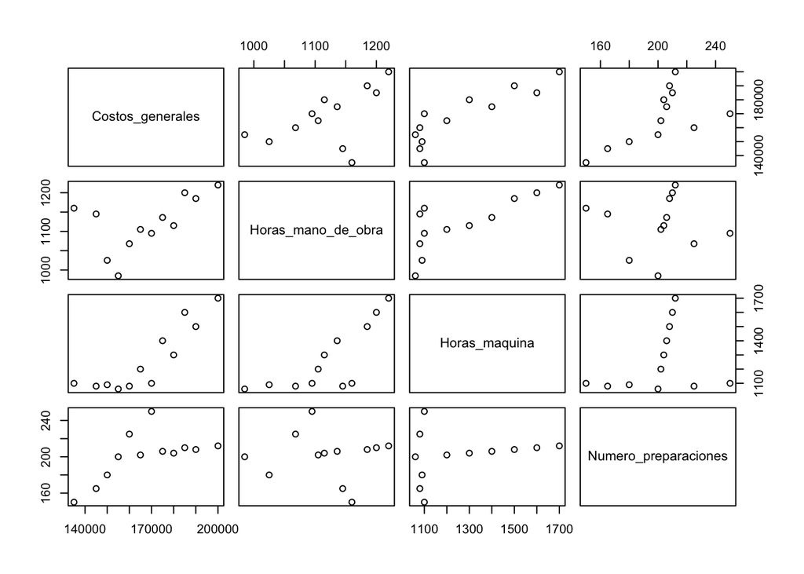

```r
pairs(datos)
```

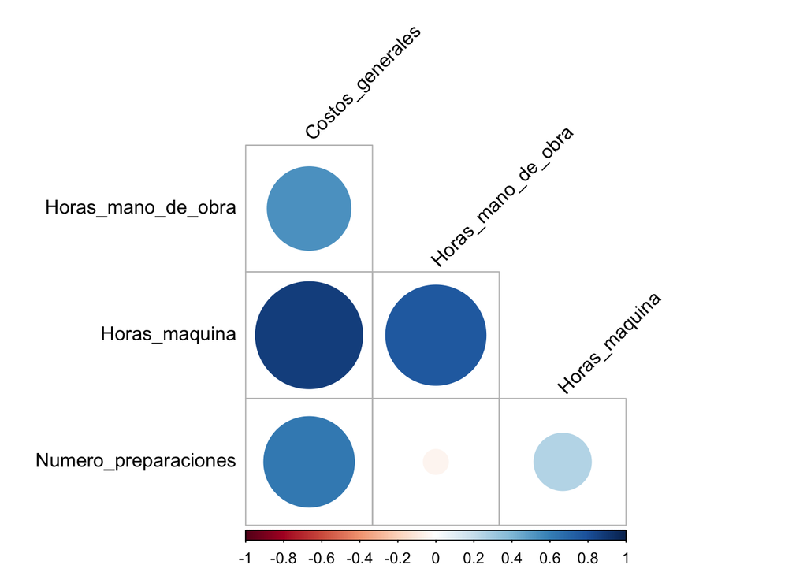

```r
corrplot(r, method="circle", type="lower", diag=FALSE,
         tl.col="black", tl.cex=1, tl.srt=45)
```

**Nota**

🔍 **Interpretación pedagógica:**  
- Valores altos en la correlación entre regresores → **multicolinealidad**.  
- Esto puede inflar varianzas de los estimadores y hacer inestables los coeficientes.  
- La matriz y el `corrplot` permiten detectar problemas antes de ajustar el modelo.

# 5 Modelo de regresión múltiple

Ajustamos el modelo:

$$\text{Costos} = \beta_0 + \beta_1(\text{Horas\_maquina}) + \beta_2(\text{Numero\_preparaciones}) + \varepsilon$$

```r
modelo <- lm(Costos_generales ~ Horas_maquina + Numero_preparaciones, data=datos)
summary(modelo)
```

```
Call:
lm(formula = Costos_generales ~ Horas_maquina + Numero_preparaciones,
    data = datos)

Residuals:
   Min     1Q Median     3Q    Max
 -7157  -2827    768   1449   9407

Coefficients:
                     Estimate Std. Error t value Pr(>|t|)
(Intercept)          19796.44   12787.83   1.548 0.156013
Horas_maquina           65.44       6.74   9.709 4.57e-06 ***
Numero_preparaciones   322.21      58.66   5.493 0.000384 ***
---
Signif. codes:  0 '***' 0.001 '**' 0.01 '*' 0.05 '.' 0.1 ' ' 1

Residual standard error: 4951 on 9 degrees of freedom
Multiple R-squared:  0.9472,    Adjusted R-squared:  0.9354
F-statistic: 80.66 on 2 and 9 DF,  p-value: 1.792e-06
```

**Nota**

# 6 Residuos del modelo

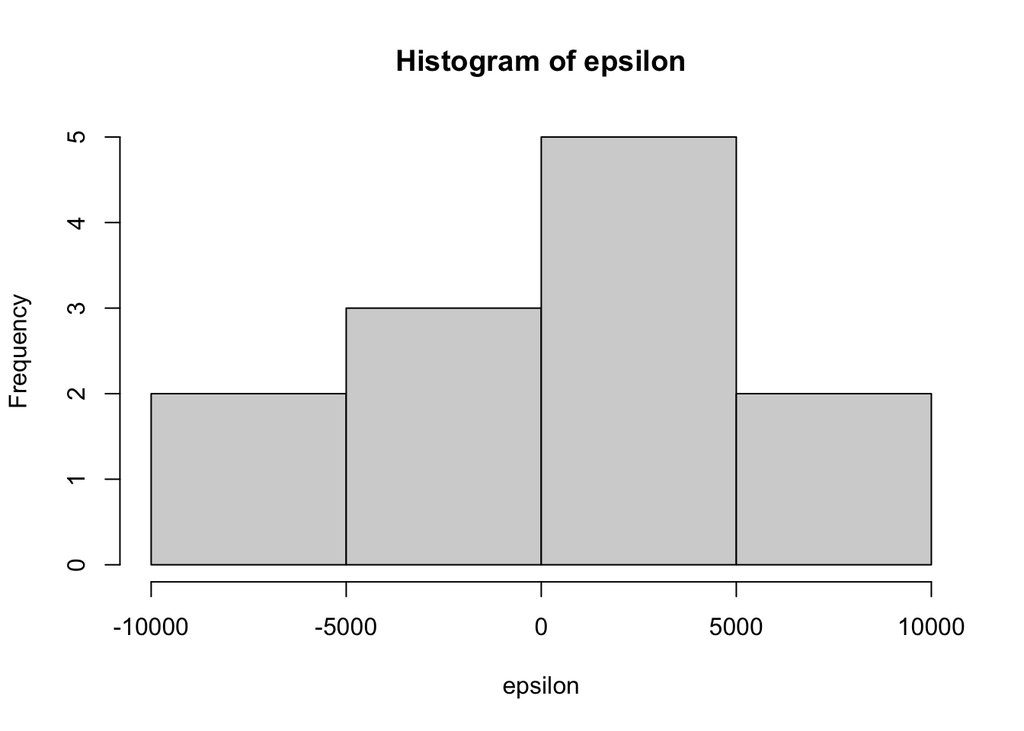

```r
epsilon <- modelo$residuals
hist(epsilon)
```

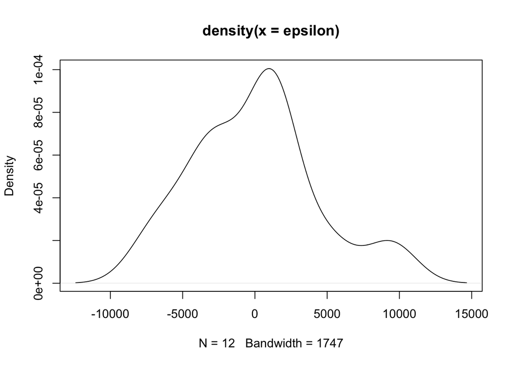

```r
plot(density(epsilon))
```

```r
mean(epsilon)
```

```
[1] 1.705303e-13
```

### 6.0.1 Normalidad de los residuos

```r
shapiro.test(epsilon)
```

```
    Shapiro-Wilk normality test

data:  epsilon
W = 0.95577, p-value = 0.7222
```

### 6.0.2 Autocorrelación (Durbin–Watson)

```r
dwtest(modelo, alternative="two.sided", iterations=1000)
```

```
    Durbin-Watson test

data:  modelo
DW = 2.0815, p-value = 0.7416
alternative hypothesis: true autocorrelation is not 0
```

Interpretación: - DW ≈ 2 → no autocorrelación  
- DW < 2 → autocorrelación positiva  
- DW > 2 → autocorrelación negativa

### 6.0.3 Heterocedasticidad (Breusch–Pagan)

```r
bptest(modelo)
```

```
    studentized Breusch-Pagan test

data:  modelo
BP = 1.0153, df = 2, p-value = 0.6019
```

# 7 Estadístico F calculado a mano

```r
R2 <- 0.9472
F <- (R2/2)/((1-R2)/(12-3))
F
```

```
[1] 80.72727
```

```r
qf(0.05, 2, 9, lower.tail=FALSE)
```

```
[1] 4.256495
```

Interpretación: si F calculado > F crítico → el modelo **aporta información significativa**.

# 8 Desviación estándar del error

```r
s <- sqrt(sum(epsilon^2)/(12-2-1))
s
```

```
[1] 4951.106
```

# 9 Intervalos de confianza de los coeficientes

```r
confint(modelo)
```

```
                           2.5 %     97.5 %
(Intercept)          -9131.64046 48724.5095
Horas_maquina           50.18894    80.6827
Numero_preparaciones   189.50994   454.9046
```

### 9.0.1 Cálculo manual del intervalo

```r
se <- sqrt(diag(vcov(modelo)))
t <- -1*qt(0.025, 12-2-1, lower.tail=FALSE)

BHM <- 65.44
sbhm <- 6.74

limitsupBHM <- BHM + t*sbhm
limitinfBHM <- BHM - t*sbhm
limitsupBHM; limitinfBHM
```

```
[1] 50.19306
```

```
[1] 80.68694
```

# 10 Intervalo para la varianza del error

```r
gamma1 <- qchisq(0.025, 12-2-1)
gamma2 <- qchisq(0.975, 12-2-1)

s2_LI <- (12-2-1) * s^2 / gamma2
s2_LS <- (12-2-1) * s^2 / gamma1

s2_LI; s2_LS
```

```
[1] 11597739
```

```
[1] 81699732
```

# 11 Predicción puntual

```r
nuevo <- data.frame(Horas_maquina=2000, Numero_preparaciones=220)

valor_predicho <- predict(modelo, newdata=nuevo)
valor_predicho
```

```
       1
221553.7
```

# 12 Intervalo de confianza con `predict`

```r
valor_predicho2 <- predict(modelo, newdata=nuevo, interval="confidence")
valor_predicho2
```

```
       fit      lwr      upr
1 221553.7 210265.6 232841.8
```

# 13 Predicción manual paso a paso

Construimos la matriz (X):

```r
X <- cbind(1, datos$Horas_maquina, datos$Numero_preparaciones)
M <- solve(t(X) %*% X)
beta <- M %*% t(X) %*% datos$Costos_generales

x0 <- c(1, 2000, 220)
h0 <- t(x0) %*% M %*% x0

y0 <- t(beta) %*% x0
y0
```

```
         [,1]
[1,] 221553.7
```

### 13.0.1 Intervalo manual

```r
y_limsup <- y0 + s*sqrt(1+h0)*qt(0.975, 12-2-1, lower.tail=FALSE)
y_liminf <- y0 - s*sqrt(1+h0)*qt(0.975, 12-2-1, lower.tail=FALSE)

y_liminf; y_limsup
```

```
         [,1]
[1,] 237455.4
```

```
         [,1]
[1,] 205651.9
```

# 14 Gráfico Y real vs Y predicho

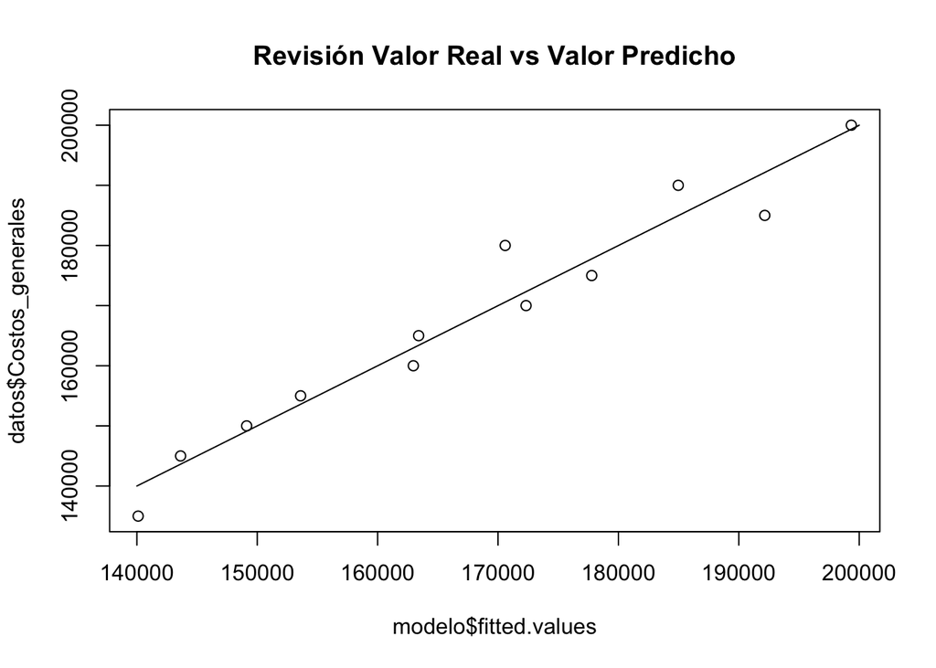

```r
plot(modelo$fitted.values, datos$Costos_generales,
     main="Revisión Valor Real vs Valor Predicho")
lines(c(140000,200000), c(140000,200000))
```

# 15 Modelo sin constante

```r
modelo2 <- lm(Costos_generales ~ Horas_maquina + Numero_preparaciones - 1, data=datos)
summary(modelo2)
```

```
Call:
lm(formula = Costos_generales ~ Horas_maquina + Numero_preparaciones -
    1, data = datos)

Residuals:
    Min      1Q  Median      3Q     Max
-9042.2 -3486.9   739.7  3467.0  9300.3

Coefficients:
                     Estimate Std. Error t value Pr(>|t|)
Horas_maquina          69.994      6.472  10.814 7.72e-07 ***
Numero_preparaciones  390.723     41.098   9.507 2.52e-06 ***
---
Signif. codes:  0 '***' 0.001 '**' 0.01 '*' 0.05 '.' 0.1 ' ' 1

Residual standard error: 5286 on 10 degrees of freedom
Multiple R-squared:  0.9992,    Adjusted R-squared:  0.999
F-statistic:  6095 on 2 and 10 DF,  p-value: 3.699e-16
```

### 15.0.1 Análisis de residuos modelo sin constante

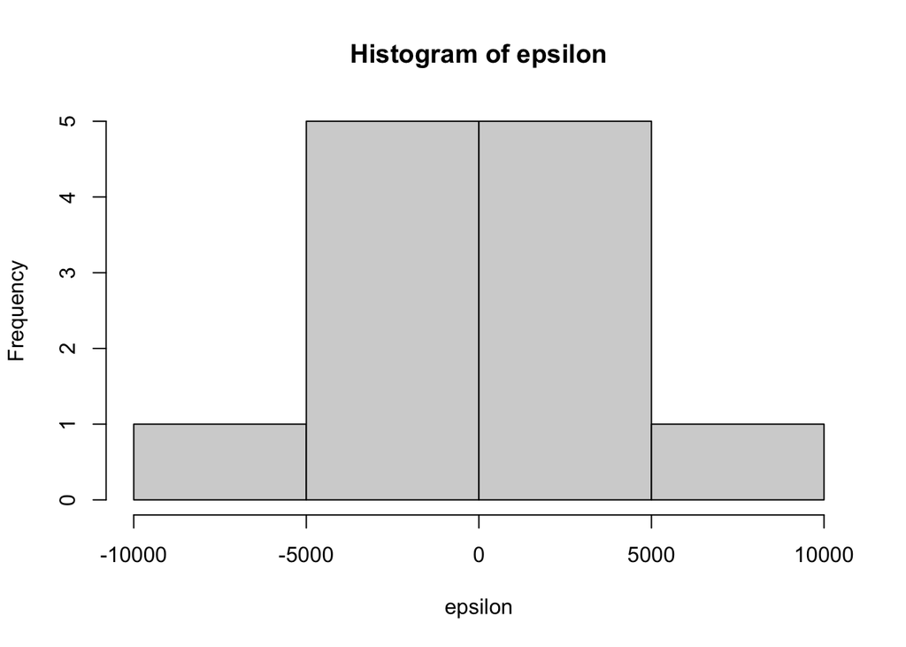

```r
epsilon <- modelo2$residuals
hist(epsilon)
```

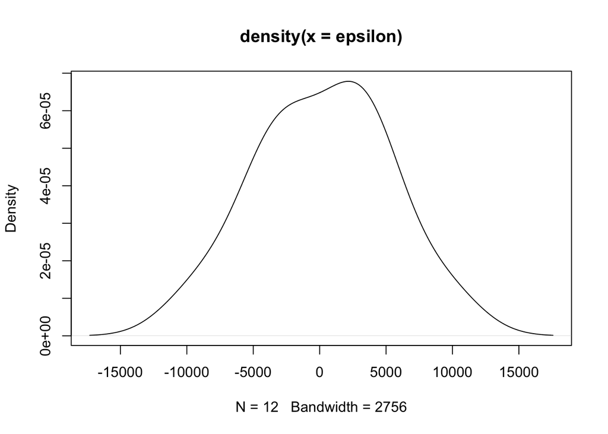

```r
plot(density(epsilon))
```

```r
shapiro.test(epsilon)
```

```
    Shapiro-Wilk normality test

data:  epsilon
W = 0.97973, p-value = 0.9825
```

```r
dwtest(modelo2,alternative="two.sided",iterations=1000)
```

```
    Durbin-Watson test

data:  modelo2
DW = 2.1284, p-value = 0.9776
alternative hypothesis: true autocorrelation is not 0
```

```r
bptest(modelo2)
```

```
    studentized Breusch-Pagan test

data:  modelo2
BP = 0.33027, df = 1, p-value = 0.5655
```